# captions

Charles T. Gray

20/05/2019

```r
# packages
library(tidyverse)
library(metasim)
library(kableExtra)
library(dplyr)
library(latex2exp)

# set winners
conflicted::conflict_prefer("filter", "dplyr")
conflicted::conflict_prefer("group_rows", "kableExtra")
```

## simulate

```r
ss <- metasims(single_study = TRUE, trial_fn = singletrial)
```

```
##
## performing  12  simulations of  3  trials
```

```r
ma <- metasims()
```

```
##
## performing  108  simulations of  3  trials
```

## single-study simulation figure

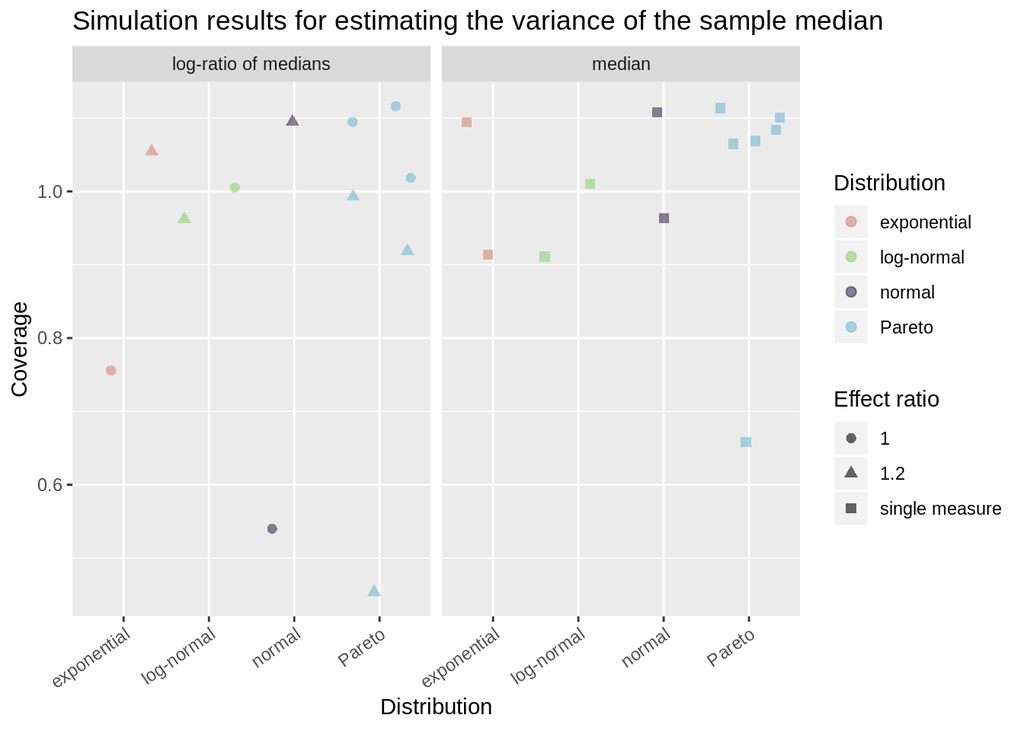

```r
ss %>% plot()
```

1. These simulation results are summarised by the proportion, coverage, of 3 confidence intervals that contain the true measure $\nu$, or log-ratio $\log(\rho)$ of control $\nu_C$ and intervention $\nu_I$ measures, with $\rho := \nu_I/\nu_C$.

Summary statistics were calculated from the samples, for the estimator of the variance $\mathcal V(m)$ of the sample median. For each of the 3 trials, a confidence interval, $\theta \pm \Phi^{-1}(0.975) \sqrt{\mathcal V(\theta)}$, was calculated, where $\theta$ estimates the true medianor log-ratio of control and intervention medians.

# before

```r
trials <- 10
unequal_effect_ratio <- 1.2
k <- c(3, 7)
tau_sq_true <- seq(0, 0.4, by = 0.2)
```

```r
sim_parameter <- function(sim, arg){

  sim %>%
    purrr::pluck("arguments") %>%
    dplyr::filter(argument == arg) %>%
    purrr::pluck("value")
}
```

```r
# parameters
(unequal_effect_ratio <- sim %>% sim_parameter("unequal_effect_ratio") %>%
   as.numeric())

trials <- sim %>% sim_parameter("trials") %>% as.numeric()
```

## only for meta-analysis

```r
(k <- sim %>% sim_parameter("k") %>% parse(text = .) %>% eval())

(tau_sq_true <- sim %>% sim_parameter("tau_sq_true") %>% parse(text = .) %>% eval())
```

# distributions caption

2. Data for the control and intervention arms were sampled from distributions: the normal distribution, with parameters 2 and 0.3, the exponential distribution, with parameters 2, the Pareto distribution, with parameters 3 and 3, the Pareto distribution, with parameters 2 and 1, the Pareto distribution, with parameters 0.5 and 1, the log-normal distribution, with parameters 1 and 0.3.

# plot caption

1. These simulation results are summarised by the proportion, coverage, of 10 confidence intervals that contain the true measure $\nu$, or log-ratio $\log(\rho)$ of control $\nu_C$ and intervention $\nu_I$ measures, with $\rho := \nu_I/\nu_C$.

## Caption for the simulation

The case where the control median $\nu_C$ is equal to the intervention median $\nu_I$ is considered, $\rho= 1$, as is an unequal ratio, $\rho =$ 1.2.

Summary statistics were calculated from the samples, for the estimator of the variance $\mathcal V(m)$ of the sample median.

### meta-analysis only

Simulations, 10 trials, were performed for each of $K =$ 3, 7 studies.

The cases where there where there is no variation between the studies, $\tau^2 = 0$, and some variation introduced by independent factors other than the measure of interest for a given study, $\tau^2 =$ 0.2, 0.4 are provided.

```r
# todo tau2
```

### single-study simulation

For each of the 10 trials, a confidence interval, $\theta \pm \Phi^{-1}(0.975)\mathcal \sqrt(V(\theta))$, was calculated, where $\theta$ estimates the true measure, or log-ratio of control and intervention measures.